# Corruption Index VS Human Development Index Plot

## Problem Statement :

To recreate visualization like “The Economist - Corruption and development(http://www.economist.com/node/21541178),using HDI(Human Development Index) and CPI(Corruption Perception Index) data .  
Sample data(Economist_Assignment_Data.csv) is available in this directory only.

## Solution :

This is demonstration of my approach and how have I tried generating a graph mentioned in problem statement.

1. Load data

```r
library(data.table)
df_hdi_cpi <- fread('Economist_Assignment_Data.csv',drop=1)
head(df_hdi_cpi)
```

```
##        Country HDI.Rank   HDI CPI            Region
## 1: Afghanistan      172 0.398 1.5      Asia Pacific
## 2:     Albania       70 0.739 3.1 East EU Cemt Asia
## 3:     Algeria       96 0.698 2.9              MENA
## 4:      Angola      148 0.486 2.0               SSA
## 5:   Argentina       45 0.797 3.0          Americas
## 6:     Armenia       86 0.716 2.6 East EU Cemt Asia
```

2. Explore data  
   find distinct number of countries, regions, number of countries per regions

```r
length(unique(df_hdi_cpi$Region))
```

```
## [1] 6
```

```r
length(unique(df_hdi_cpi$Country))
```

```
## [1] 173
```

```r
library(dplyr)
summarize(group_by(df_hdi_cpi, Region), countriey_count = n()) %>% arrange(countriey_count)
```

```
## # A tibble: 6 × 2
##              Region countriey_count
##               <chr>           <int>
## 1 East EU Cemt Asia              18
## 2              MENA              18
## 3      Asia Pacific              30
## 4      EU W. Europe              30
## 5          Americas              31
## 6               SSA              46
```

There are 2 columns which should be explored - HDI and CPI. This is what is represented in target plot also.

3. Plotting

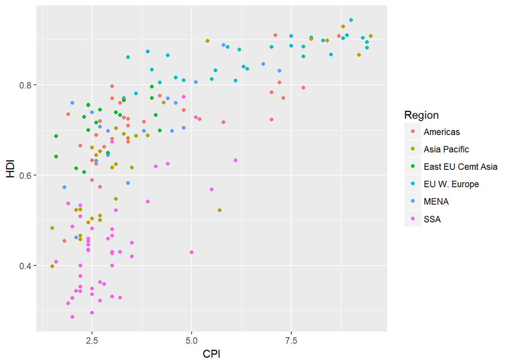

```r
library(ggplot2)
plot_basic <- ggplot(df_hdi_cpi, aes(x = CPI, y = HDI, color = Region)) + geom_point()
print(plot_basic)
```

Add trend line - Regression line here - look at final impage that has to be achieved

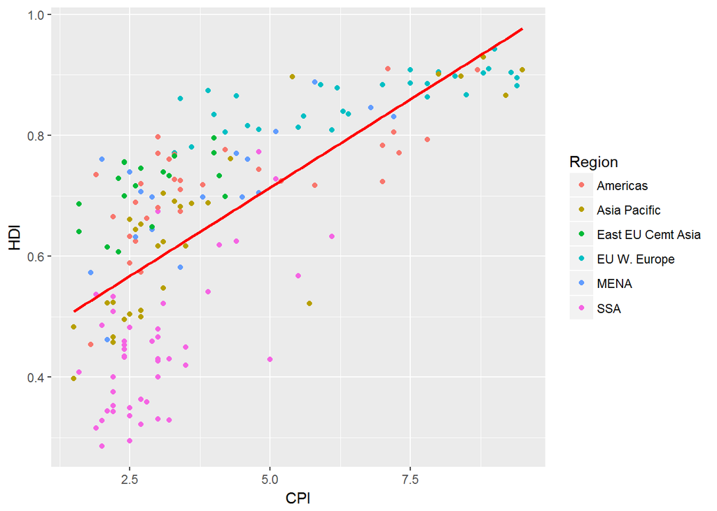

```r
plot_regression <- plot_basic + geom_smooth(aes(group = 1), method = 'lm', formula = y~x, se = F, color = 'red')
print(plot_regression)
```

Required output line is not linear, its log

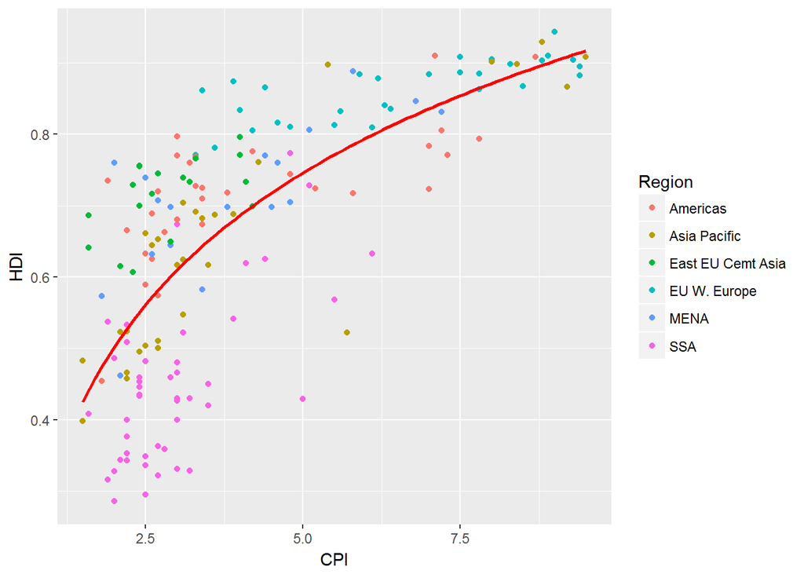

```r
plot_regression <- plot_basic + geom_smooth(aes(group = 1), method = 'lm', formula = y ~ log(x), se = F, color = 'red')
print(plot_regression)
```

Adding labels to circles

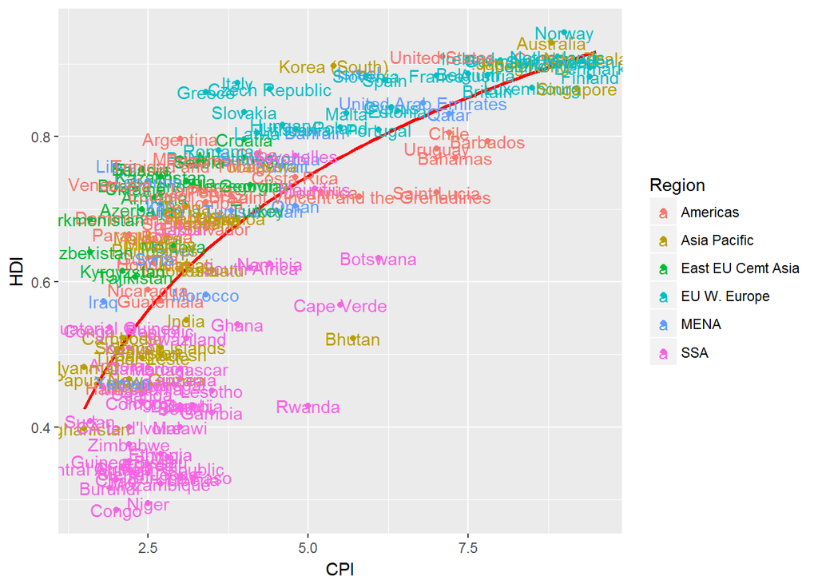

```r
print(plot_regression + geom_text(aes(label=Country)))
```

We dont need all countries in plot final image  
(Look at the impage and list down names of all countries required)

```r
pointsToLabel <- c("Russia", "Venezuela", "Iraq", "Myanmar", "Sudan",
                   "Afghanistan", "Congo", "Greece", "Argentina", "Brazil",
                   "India", "Italy", "China", "South Africa", "Spane",
                   "Botswana", "Cape Verde", "Bhutan", "Rwanda", "France",
                   "United States", "Germany", "Britain", "Barbados", "Norway", "Japan",
                   "New Zealand", "Singapore")
```

Plot only those countries which are required on final plot

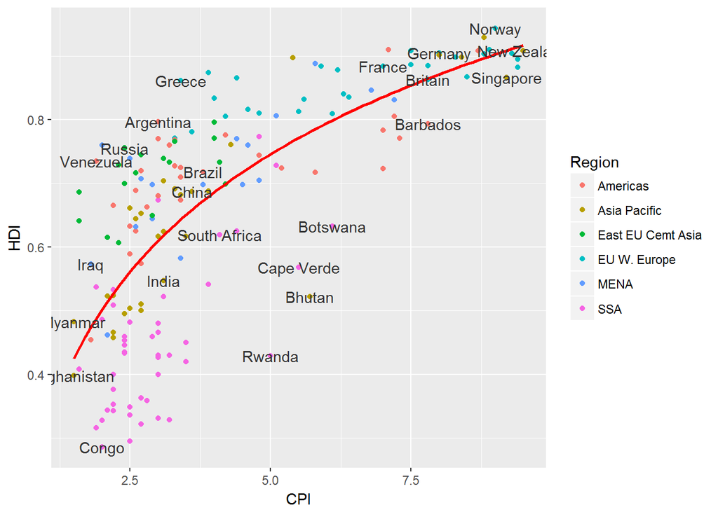

```r
plot_required_countries <- plot_regression + geom_text(aes(label = Country), color = "gray20",
                                                       data = subset(df_hdi_cpi, Country %in% pointsToLabel),check_overlap = TRUE)
print(plot_required_countries)
```

Make circles hollow

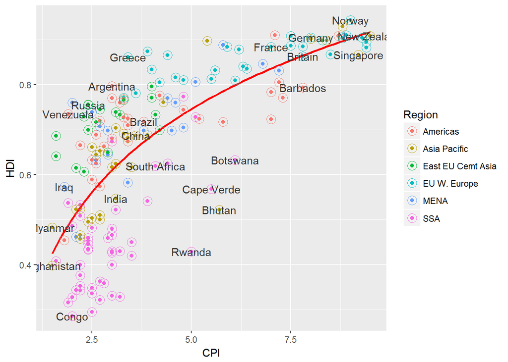

```r
plot_required_countries <- plot_required_countries + geom_point(size=4,shape=1)
print(plot_required_countries)
```

Not as expected.  
apply this to first plot

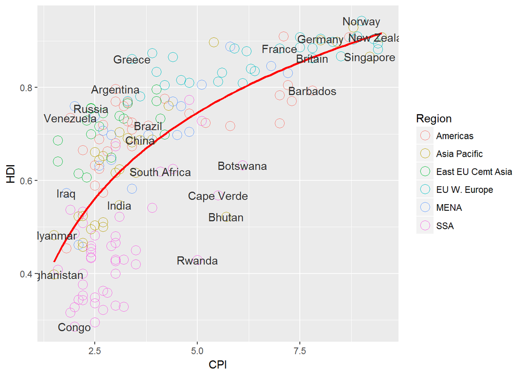

```r
plot_required_countries <- ggplot(df_hdi_cpi, aes(x = CPI, y = HDI, color = Region)) + geom_point(size=4,shape=1) +
        geom_smooth(aes(group = 1), method = 'lm', formula = y ~ log(x), se = F, color = 'red') +
        geom_text(aes(label = Country), color = "gray20", data = subset(df_hdi_cpi, Country %in% pointsToLabel),check_overlap = TRUE)
print(plot_required_countries)
```

Adding headings etc

```r
plot_x_y_axis <- plot_required_countries + scale_x_continuous(name = "Corruption Perceptions Index, 2011 (10=least corrupt)" ) + scale_y_continuous(name = "Human Development Index, 2011 (1=Best)")
```

Adding upper heading + theme

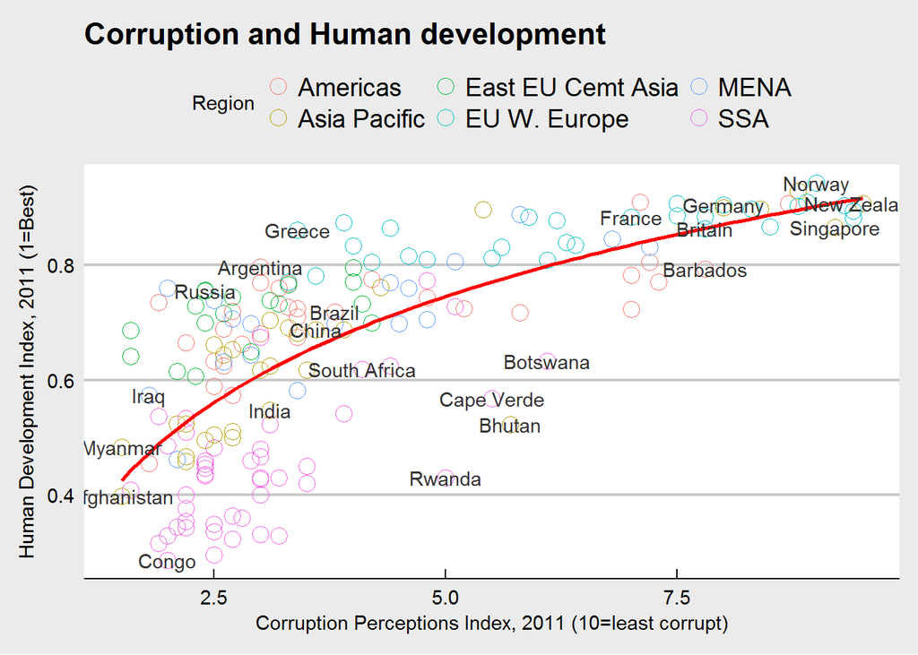

```r
library(ggthemes)
plot_hdi_cpi_final <- plot_x_y_axis + ggtitle("Corruption and Human development") + theme_economist_white()
print(plot_hdi_cpi_final)
```